# Adding Non-Linearity To The Right Hand Side Of An Equation for Categorical Data

Categorical Data Analysis

Andy Grogan-Kaylor https://agrogan1.github.io/ (University of Michigan)https://www.umich.edu  
2021-12-16

# Introduction

Logistic regression models the *log odds* of an outcome as a function of a set of covariates:

$$\ln \Big(\frac{p(\text{outcome})}{1-p(\text{outcome})} \Big) = \beta_0 + \beta_1 x_1 + \beta_2 x_2$$
Here $p(\text{outcome})$ is the probability of the outcome.

$\frac{p(\text{outcome})}{1-p(\text{outcome})}$ is the *odds* of the outcome.

Hence, $\ln \Big(\frac{p(\text{outcome})}{1-p(\text{outcome})} \Big)$ is the *log odds*.

> It is plausible to think about adding non-linear functions of the covariates–e.g. $\ln(x)$, $x^2$–to the right hand side of our logistic regression equation.

# Consider Again The Equation For Logistic Regression

$$\ln \Big(\frac{p(\text{outcome})}{1-p(\text{outcome})} \Big) = \beta_0 + \beta_1 x_1 + \beta_2 x_2$$

> A logistic regression is **already** a **non-linear** model because of the transformed y variable.

> A logistic regression creates a **non-linear** model of probabilities by being a **linear** model of the log-odds.

# Visual Considerations

Plotting a logistic regression curve helps us to see the non-linearity of the equation.

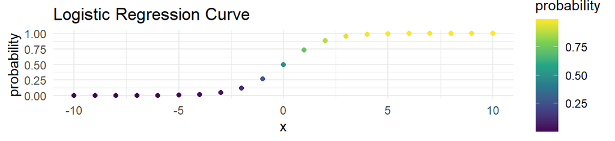

It may sometimes appear that the plotted curve is linear.

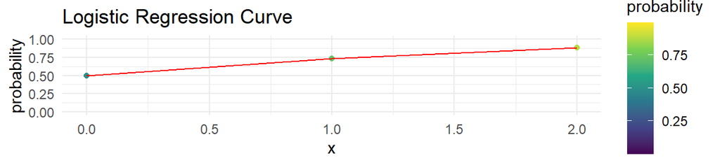

But this is only a result of the fact that we are only using a portion of the logistic regression curve for a particular analysis.

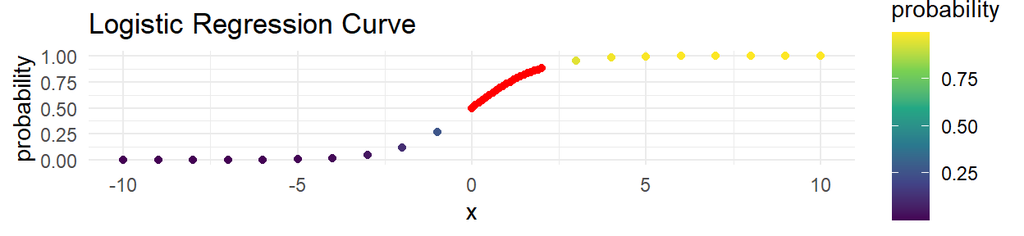

# Conclusion

The basic logistic regression equation is:

$$\ln \Big(\frac{p(\text{outcome})}{1-p(\text{outcome})} \Big) = \beta_0 + \beta_1 x_1 + \beta_2 x_2$$

The model is already *non-linear* because of the *transformed y variable*. We can certainly add non-linear terms to the right hand side of the model (e.g. $x^2$) but this will add non-linearity **on top of the already existing non-linearity** that is due to the *transformed dependent variable*.

We may indeed find that these non-linear terms on the right hand side of the equation are statistically significant, but will need to think carefully about the conceptual and substantive implications of the model given the *potentially multiple layers of non-linearity*.